# The Project

1. This is a project with minimal scaffolding. Expect to use the the discussion forums to gain insights! It’s not cheating to ask others for opinions or perspectives!
2. Be inquisitive, try out new things.
3. Use the previous modules for insights into how to complete the functions! You'll have to combine Pillow, OpenCV, and Pytesseract
4. There are hints provided in Coursera, feel free to explore the hints if needed. Each hint provide progressively more details on how to solve the issue. This project is intended to be comprehensive and difficult if you do it without the hints.

### The Assignment

Take a ZIP file) of images and process them, using a [library built into python](https://docs.python.org/3/library/zipfile.html) that you need to learn how to use. A ZIP file takes several different files and compresses them, thus saving space, into one single file. The files in the ZIP file we provide are newspaper images (like you saw in week 3). Your task is to write python code which allows one to search through the images looking for the occurrences of keywords and faces. E.g. if you search for "pizza" it will return a contact sheet of all of the faces which were located on the newspaper page which mentions "pizza". This will test your ability to learn a new ([library](https://docs.python.org/3/library/zipfile.html)), your ability to use OpenCV to detect faces, your ability to use tesseract to do optical character recognition, and your ability to use PIL to composite images together into contact sheets.

Each page of the newspapers is saved as a single PNG image in a file called images.zip. These newspapers are in english, and contain a variety of stories, advertisements and images. Note: This file is fairly large (~200 MB) and may take some time to work with, I would encourage you to use small_img.zip for testing.

Here's an example of the output expected. Using the small_img.zip file, if I search for the string "Christopher" I should see the following image:

[figure not shown]

If I were to use the images.zip file and search for "Mark" I should see the following image (note that there are times when there are no faces on a page, but a word is found!):

[figure not shown]

Note: That big file can take some time to process - for me it took nearly ten minutes! Use the small one for testing.

```python
import zipfile
import os
import numpy as np
from PIL import Image
import pytesseract
import cv2 as cv
from IPython.display import display
from matplotlib import pyplot as plt


# loading the face detection classifier
face_cascade = cv.CascadeClassifier('readonly/haarcascade_frontalface_default.xml')
```

```python
zip_file_path = 'readonly/images.zip'
```

```python
#create a dictionary and iterate

image_data = {}

with zipfile.ZipFile(zip_file_path, 'r') as zip_file:
    for file_info in zip_file.infolist():
        with zip_file.open(file_info) as file:
            image_array = np.asarray(bytearray(file.read()), dtype=np.uint8)
            cv_image = cv.imdecode(image_array, cv.IMREAD_COLOR)

            # Convert to grayscale
            gray_image = cv.cvtColor(cv_image, cv.COLOR_BGR2GRAY)

            # Detect faces
            faces = face_cascade.detectMultiScale(gray_image, scaleFactor=1.3, minNeighbors=5)

            # Store faces in image_data dictionary
            image_data[file_info.filename] = {'image': cv_image, 'faces': faces}
```

```python
# using pytesseract library to extract text from each image

for filename, data in image_data.items():
    if 'image' in data:  # Check if 'image' key is present
        # Convert OpenCV image to PIL Image
        pil_image = Image.fromarray(cv.cvtColor(data['image'], cv.COLOR_BGR2RGB))
        text = pytesseract.image_to_string(pil_image)
        image_data[filename]['text'] = text
```

```
Results found in a-0.png:
Keyword 'Christopher' found in a-0.png
Keyword 'Mark' found in a-0.png
```

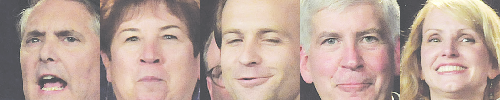

```
Results found in a-1.png:
Keyword 'Mark' found in a-1.png
```

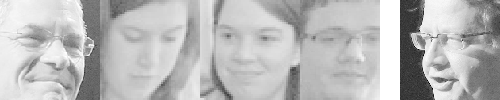

```
Results found in a-10.png:
But there were no faces in the file
Results found in a-11.png:
But there were no faces in the file
Results found in a-12.png:
But there were no faces in the file
Results found in a-13.png:
Keyword 'Mark' found in a-13.png
```

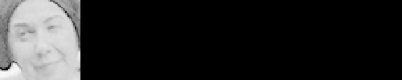

```
Results found in a-2.png:
Keyword 'Mark' found in a-2.png
```

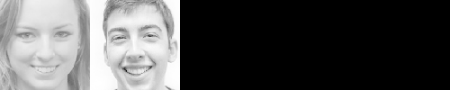

```
Results found in a-3.png:
Keyword 'Christopher' found in a-3.png
Keyword 'Mark' found in a-3.png
```

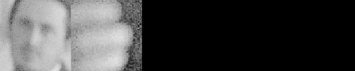

```
Results found in a-4.png:
But there were no faces in the file
Results found in a-5.png:
```

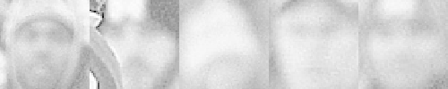

```
Results found in a-6.png:
```

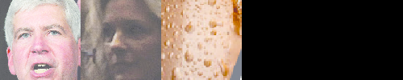

```
Results found in a-7.png:
But there were no faces in the file
Results found in a-8.png:
But there were no faces in the file
Results found in a-9.png:
```

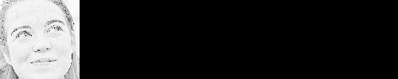

```python
#Search for the correct keywords
keywords = ["Christopher", "Mark"]

for filename, data in image_data.items():
    text = data.get('text', '')
    print(f"Results found in {filename}:")

    faces = data.get('faces', [])

    if len(faces) == 0:
        print(f"But there were no faces in the file")
        continue

    for keyword in keywords:
        if keyword in text:
            print(f"Keyword '{keyword}' found in {filename}")

    # Create a contact sheet with faces found
    contact_sheet = Image.new('RGB', (500, 100))
    x = 0

    for (x_, y_, w_, h_) in faces:
        face = data['image'][y_:y_ + h_, x_:x_ + w_].copy()
        face = Image.fromarray(cv.cvtColor(face, cv.COLOR_BGR2RGB)).resize((100, 100))
        contact_sheet.paste(face, (x, 0))
        x += 100

    display(contact_sheet)
```